# Clientes que vuelven: Propensity to Return con IA y ROI

Author

BI Evolution

## Resumen ejecutivo

Este análisis construye un **modelo de Propensity to Return** para estimar  
la **probabilidad de que un cliente vuelva a comprar en los próximos 90 días**.

Con este modelo podemos:

- Detectar **qué clientes tienen más probabilidad de volver**.
- Asignar el esfuerzo comercial (llamadas, WhatsApp) a quienes generan **mayor retorno**.
- Comparar el **ROI** entre dos estrategias:
1. 500 llamadas **al azar**.
2. 500 llamadas **dirigidas por IA** a los clientes con mayor probabilidad de retorno.

El objetivo es demostrar, en términos económicos, **cuánto más rentable** es priorizar decisiones con IA en negocios peruanos.

## 1. Resultado principal del modelo

### 1.1. Modelo ganador y desempeño global

En la práctica, el equipo solo puede realizar **500 llamadas personalizadas** en cada ciclo.

Comparamos dos estrategias:

- **Sin modelo:** 500 llamadas por orden de llegada / al azar.
- **Con IA:** 500 llamadas a quienes **más probabilidad** tienen de volver.

Esto demuestra que no es “magia del algoritmo”, sino mejor uso de la misma capacidad.

# 🔵 **Embudo real de retorno (baseline)**

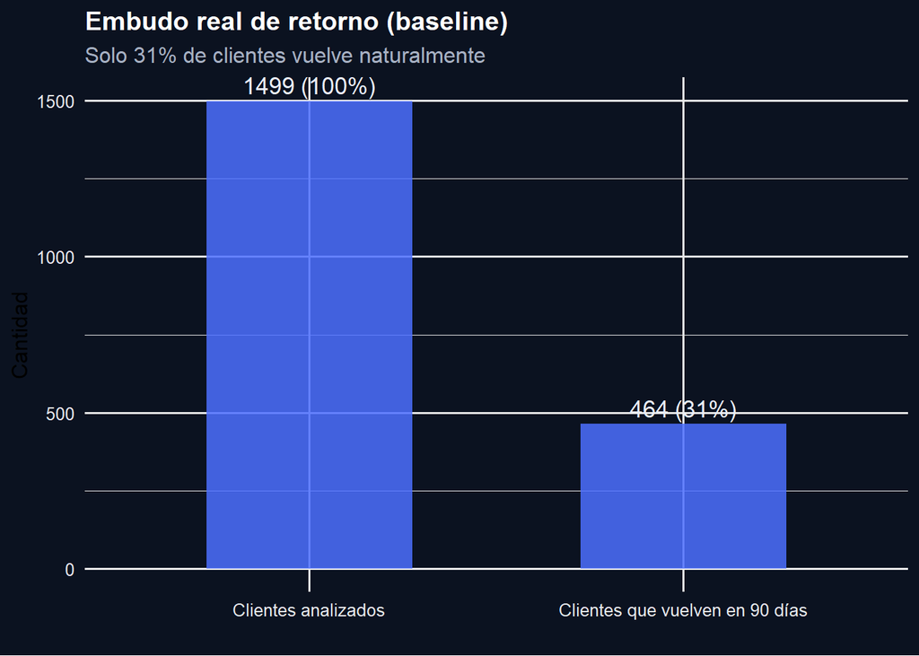

> **Interpretación:** El embudo confirma que solo una fracción pequeña vuelve. Esto hace que llamar al azar sea **muy ineficiente**, justificando el modelo.

## 1.2. Matriz de confusión con costos asociados

Matriz de confusión del modelo (set de prueba)

[output not shown]

### **Impacto económico**

Impacto económico por tipo de resultado

[output not shown]

# 🔵 Curva de Ganancias (Cumulative Gains Chart)

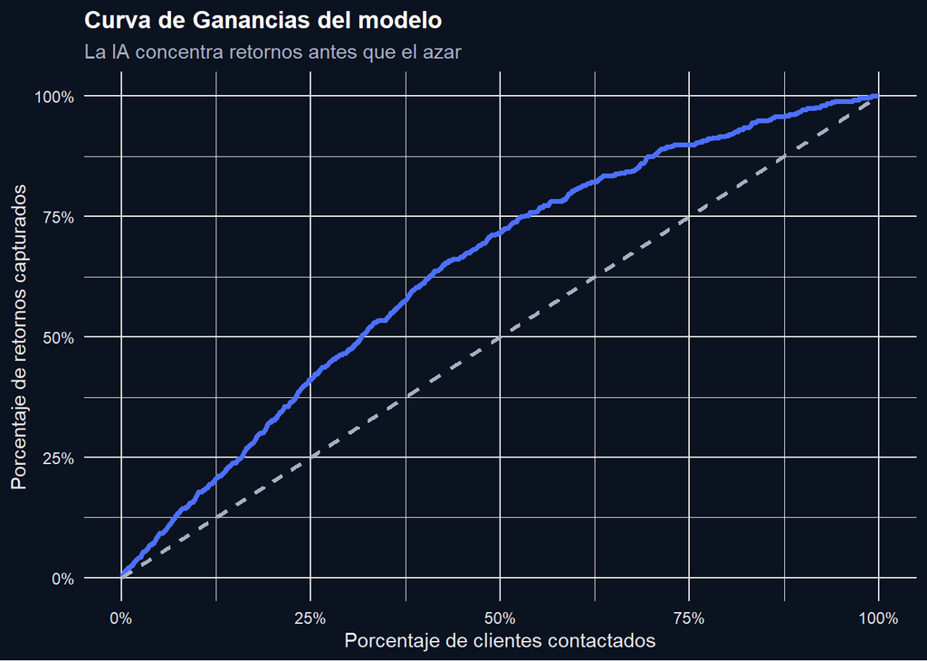

## 1.3. Comparativa visual del ROI

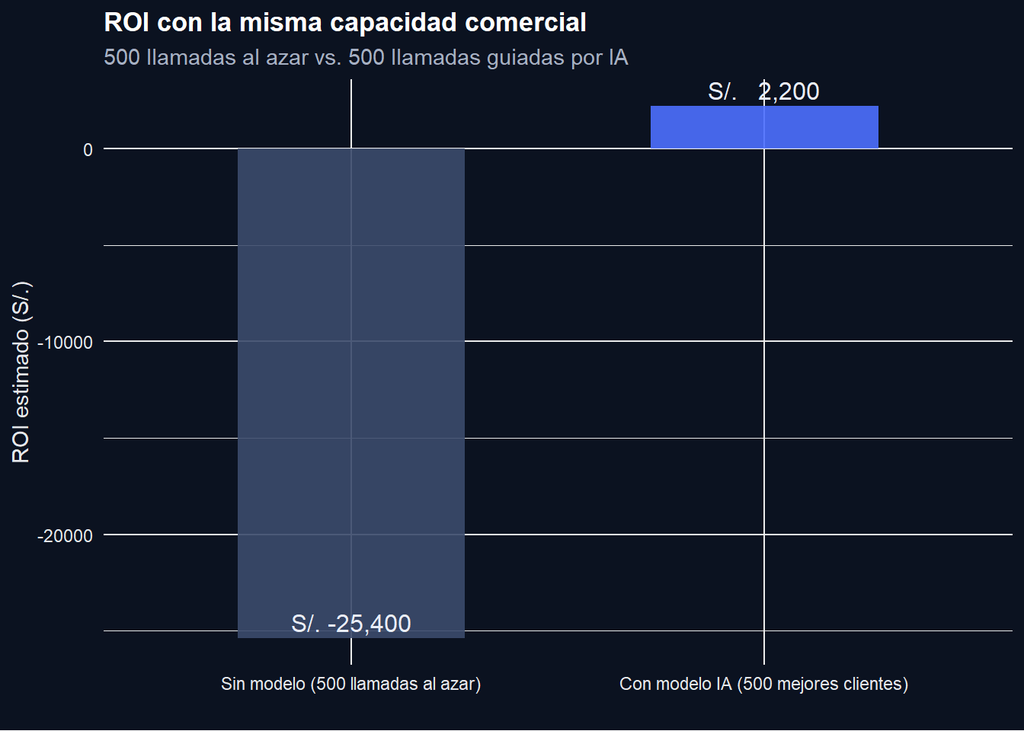

# 2. Datos utilizados

Muestra de la base de clientes

| id_cliente | segmento | dias_desde_ultima_compra | num_compras_12m | ticket_promedio | canal_favorito | respondio_campania_anterior | uso_cupon | satisfaccion | volvio_90dias |
| --- | --- | --- | --- | --- | --- | --- | --- | --- | --- |
| 1 | Ocasional | 80 | 3 | 209.10 | Tienda | 0 | 1 | 3 | No |
| 2 | Alta frecuencia | 18 | 8 | 143.02 | Tienda | 1 | 0 | 4 | Sí |
| 3 | Alta frecuencia | 11 | 17 | 218.98 | Online | 0 | 0 | 3 | Sí |
| 4 | Ocasional | 66 | 3 | 185.87 | Tienda | 0 | 0 | 3 | No |
| 5 | Ocasional | 10 | 5 | 191.96 | Tienda | 0 | 0 | 3 | No |
| 6 | Ocasional | 85 | 3 | 110.74 | Tienda | 0 | 0 | 3 | Sí |
| 7 | Nuevo | 149 | 0 | 175.56 | Online | 0 | 0 | 3 | No |
| 8 | Ocasional | 15 | 7 | 96.28 | Tienda | 0 | 0 | 3 | Sí |

# 3. Modelos evaluados

Comparativo de modelos (ROC en CV)

| Modelo | ROC mínimo (CV) | ROC medio (CV) | ROC máximo (CV) |
| --- | --- | --- | --- |
| XGBoost | 0.675 | 0.695 | 0.718 |
| Regresión logística | 0.678 | 0.695 | 0.707 |
| Random Forest | 0.658 | 0.672 | 0.690 |
| SVM | 0.630 | 0.653 | 0.683 |

# 4. Interpretación ejecutiva

El modelo asigna una probabilidad a cada cliente. Con esto se decide:

- **A quién llamar primero**
- **Cuánto esfuerzo dedicar**
- **A quién solo enviar campañas automáticas**

El resultado: **más retornos recuperados** con la misma capacidad comercial.

# 5. Próximos pasos

1. Integrar el score al CRM
2. Diseñar flujos de acción por nivel
3. Medir retorno real por segmento
4. Recalibrar costos económico-comerciales
5. Automatizar campañas basadas en IA